# Curbing the Spread of a Pandemic with Authoritarianism

Arnan Huang Summer 2021

## Background:

For centuries, the discussion of the role of government has been the center of political discourse, and yet despite the general liberalization of governments around the world, many authoritarian regimes still remain and retain broad support. Despite the general agreement, especially throughout the broadly liberalized western world, that a free and liberal government more often than not results in a happier population, it seems, at least in theory, that authoritarian governments do have some benefits.

With the appearance of COVID 19 and the resulting pandemic, the death and economic disaster left in its wake has revitalized the debate on whether authoritarian regimes may in fact dampen the effects of massive disasters such as a pandemic through more effective controls and regulations. Comparing the case numbers of an authoritarian regime such as China and that of the United States, one could hypothesize that perhaps only a strong authoritarian government would be able to mount an effective campaign against something such as a pandemic, where a liberal democracy would be unable to prevent the spread of a virus through limiting freedoms in such a way that an authoritarian government may have the institutional power to do.

## Data Source

Determining metrics for freedom and authoritarianism for countries is not as straightforward as population statistics, since there is no broadly accepted unit of democracy. How democratic a country is depends on a variety of factors including how their government is selected, how dissent is treated, or how much power the government holds to begin with.

For this investigation, we will be using the Democracy Index compiled by the Economist Group. This takes into consideration how fair the national elections are as well as the overall power that civil servants have to implement policies. The biggest reason to use this metric rather than others developed by other groups is that the Democracy Index does not take into account economic living standards, as it would not allow us to isolate specifically the authoritarian nature of the government and any conclusion made off these other indices would require further investigation into how living standards may impact the spread of COVID 19. By isolating only the governmental factors, we can isolate economic variables as controls in order to make a more narrow statement specifically about the governmental response and effect on the spread of the virus. The Democracy Index for each country was obtained from The Economist.

We also want to further study the effect of a free press on the spread of COVID 19. While an authoritarian government may have more power to implement more powerful restrictions that could curb the spread of a pandemic, some have theorized that the limitations that authoritarian regimes place on the press may prevent the distribution of information which may impact the ability of individuals within the population to effectively take precautions to prevent the spread of the pandemic. One could hypothesize that this may increase the case numbers of authoritarian regimes, an opposite effect mentioned above. Because of this, we will isolate this variable by using the Free Press Index generated by Reporters Without Borders. This index uses a variety of indicators to generate a score that broadly scores how free the media is in a given company through surveys on a given country's media independence, censorship, transparency, and infrastructure.

Covid Data was imported from the world health organization. GDP data was imported from the World Bank.

```python
pip install country_converter --upgrade
```

```python
import pandas as pd
import seaborn as sns
import numpy as np
import matplotlib.pyplot as plt
from scipy.stats import pearsonr
import country_converter as coco
```

We begin by importing COVID19 data from the WHO. Only a few of these columns will be relevant to our analysis, but we will remove these later. Here we encounter our first problem: Different resources sometimes use drastically different names for the same country. For example, in the WHO data, The Democratic People's Republic of Korea is listed with its full name, however, in the data from the Economist, they list the same country by its common name of North Korea. To solve this, we need to standardize all country names to the same name or in this case, code.

To do this, we have installed the package country_converter. This library contains a database of many different names of a country and allows us to conveert them into a standardized code, in this case, the ISO3 convention, using the CountryConverter method. This allows us to later merge the data without manually looking at non overlapping datasets and adding them back in. The method prints any country that it does not find a code for which will make it convenient for us to manually add them back if we have to.

We see five categories that do not have a country code. Global is not a country, it is the aggregation of all the data around the globe. This will not be useful since we are looking at governments and as of 2021 there is no world government. Bonaire, Sint Eustatius, and Saba are municipalities of the netherlands and thus will not have any democracy index. Other is obviously not a country so it can be ommitted.

```python
covid_data = pd.read_csv("who_data.csv")
cc = coco.CountryConverter()
covid_data['Name'] = cc.convert(names = covid_data['Name'], to = 'ISO3')
covid_data
```

```
Global not found in regex
Bonaire not found in regex
Other not found in regex
Sint Eustatius not found in regex
Saba not found in regex
```

|  | Name | WHO Region | Cases - cumulative total | Cases - cumulative total per 100000 population | Cases - newly reported in last 7 days | Cases - newly reported in last 7 days per 100000 population | Cases - newly reported in last 24 hours | Deaths - cumulative total | Deaths - cumulative total per 100000 population | Deaths - newly reported in last 7 days | Deaths - newly reported in last 7 days per 100000 population | Deaths - newly reported in last 24 hours | Transmission Classification |
| --- | --- | --- | --- | --- | --- | --- | --- | --- | --- | --- | --- | --- | --- |
| 0 | not found | NaN | 190770507 | 2447.48886 | 3420416 | 43.882203 | 408730 | 4095924 | 52.548628 | 56439 | 0.724084 | 6541 | NaN |
| 1 | USA | Americas | 33741532 | 10193.73000 | 189267 | 57.180000 | 6963 | 603880 | 182.440000 | 1682 | 0.510000 | 26 | Community transmission |
| 2 | IND | South-East Asia | 31144229 | 2256.82000 | 269853 | 19.550000 | 38164 | 414108 | 30.010000 | 5344 | 0.390000 | 499 | Clusters of cases |
| 3 | BRA | Americas | 19376574 | 9115.84000 | 286634 | 134.850000 | 34126 | 542214 | 255.090000 | 8726 | 4.110000 | 948 | Community transmission |
| 4 | RUS | Europe | 5982766 | 4099.63000 | 174293 | 119.430000 | 24633 | 149138 | 102.200000 | 5426 | 3.720000 | 719 | Clusters of cases |
| ... | ... | ... | ... | ... | ... | ... | ... | ... | ... | ... | ... | ... | ... |
| 233 | SHN | Africa | 0 | 0.00000 | 0 | 0.000000 | 0 | 0 | 0.000000 | 0 | 0.000000 | 0 | No cases |
| 234 | TKL | Western Pacific | 0 | 0.00000 | 0 | 0.000000 | 0 | 0 | 0.000000 | 0 | 0.000000 | 0 | No cases |
| 235 | TON | Western Pacific | 0 | 0.00000 | 0 | 0.000000 | 0 | 0 | 0.000000 | 0 | 0.000000 | 0 | No cases |
| 236 | TKM | Europe | 0 | 0.00000 | 0 | 0.000000 | 0 | 0 | 0.000000 | 0 | 0.000000 | 0 | No cases |
| 237 | TUV | Western Pacific | 0 | 0.00000 | 0 | 0.000000 | 0 | 0 | 0.000000 | 0 | 0.000000 | 0 | No cases |

238 rows × 13 columns

We pulled data for the democracy index from The Econonmist. Using the method above, we convert the country names to codes in order for simple cross comparisons and merging.

```python
dem_data = pd.read_csv("dem_index.csv")
dem_data = dem_data.loc[dem_data['year'] == 2020]
dem_data['country'] = cc.convert(names = dem_data['country'], to = 'ISO3')
dem_data.sort_values('country')
```

|  | country | eiu | year |
| --- | --- | --- | --- |
| 975 | AFG | 2.85 | 2020 |
| 1599 | AGO | 3.66 | 2020 |
| 299 | ALB | 6.08 | 2020 |
| 1573 | ARE | 2.70 | 2020 |
| 663 | ARG | 6.95 | 2020 |
| ... | ... | ... | ... |
| 1326 | VNM | 2.94 | 2020 |
| 1586 | YEM | 1.95 | 2020 |
| 2093 | ZAF | 7.05 | 2020 |
| 2145 | ZMB | 4.86 | 2020 |
| 2158 | ZWE | 3.16 | 2020 |

167 rows × 3 columns

### Missing Data

Here we perform an inner merge. This omits any coutnries that either do not have a EIU index or COVID 19 data. Since we are plotting EIU vs deaths or cases, if either is NaN, we drop it outright. In our case, we do not have any missing values so this is unnecessary, but if there were missing values, the country should be removed from analysis. An inner merge is performed since if either deaths or cases are missing, it would not be possible to plot deaths vs cases.

```python
comb_data = covid_data.merge(dem_data, left_on='Name', right_on='country').sort_values('Name')[['Name','Cases - cumulative total per 100000 population', "Deaths - cumulative total per 100000 population",'eiu']]
comb_data.rename(columns = {'Cases - cumulative total per 100000 population':'cases', "Deaths - cumulative total per 100000 population":"deaths"}, inplace = True)
comb_data
```

|  | Name | cases | deaths | eiu |
| --- | --- | --- | --- | --- |
| 90 | AFG | 365.84 | 16.10 | 2.85 |
| 119 | AGO | 124.15 | 2.91 | 3.66 |
| 93 | ALB | 4610.67 | 85.34 | 6.08 |
| 39 | ARE | 6698.27 | 19.21 | 2.70 |
| 7 | ARG | 10523.94 | 224.69 | 6.95 |
| ... | ... | ... | ... | ... |
| 111 | VNM | 61.83 | 0.26 | 2.94 |
| 147 | YEM | 23.43 | 4.59 | 1.95 |
| 16 | ZAF | 3869.74 | 112.73 | 7.05 |
| 83 | ZMB | 1009.84 | 16.78 | 4.86 |
| 105 | ZWE | 562.60 | 17.64 | 3.16 |

165 rows × 4 columns

GDP was used to evaluate a country's wealth, as the wealth of a country may allow it to take more measures to stop the spread of covid. We discuss further why GDP was used below. Since wealthy countries tend to be more democratic, we want to observe if wealth has a positive effect on the impact of covid on a country. This data was downloaded as a csv file from the World Bank. Country name was normalized as before to the ISO3 standard.

```python
gdp = pd.read_csv('gdp.csv')
press = pd.read_csv('press.csv')
press = press[['EN_country', 'Score 2020']]
press['EN_country'] = cc.convert(names = press['EN_country'], to = 'ISO3')
gdp['Country or Area'] = cc.convert(names = gdp['Country or Area'], to = 'ISO3')
gdp
```

```
OECS not found in regex
United Republic of Tanzania: Zanzibar not found in regex
```

|  | Country or Area | Year | Item | Value |
| --- | --- | --- | --- | --- |
| 0 | AFG | 2019 | Gross Domestic Product (GDP) | 469.919090 |
| 1 | ALB | 2019 | Gross Domestic Product (GDP) | 5303.197823 |
| 2 | DZA | 2019 | Gross Domestic Product (GDP) | 3975.510381 |
| 3 | AND | 2019 | Gross Domestic Product (GDP) | 40887.421650 |
| 4 | AGO | 2019 | Gross Domestic Product (GDP) | 2670.850732 |
| ... | ... | ... | ... | ... |
| 207 | VEN | 2019 | Gross Domestic Product (GDP) | 4732.820093 |
| 208 | VNM | 2019 | Gross Domestic Product (GDP) | 2715.275874 |
| 209 | YEM | 2019 | Gross Domestic Product (GDP) | 855.066811 |
| 210 | ZMB | 2019 | Gross Domestic Product (GDP) | 1292.482076 |
| 211 | ZWE | 2019 | Gross Domestic Product (GDP) | 1463.985913 |

212 rows × 4 columns

```python
gdp = gdp[['Country or Area', 'Value']]
df = comb_data.merge(gdp, left_on='Name', right_on='Country or Area').sort_values('Name')
df.rename(columns = {'Value':'gdp'}, inplace = True)
df
```

|  | Name | cases | deaths | eiu | Country or Area | gdp |
| --- | --- | --- | --- | --- | --- | --- |
| 0 | AFG | 365.84 | 16.10 | 2.85 | AFG | 469.919090 |
| 1 | AGO | 124.15 | 2.91 | 3.66 | AGO | 2670.850732 |
| 2 | ALB | 4610.67 | 85.34 | 6.08 | ALB | 5303.197823 |
| 3 | ARE | 6698.27 | 19.21 | 2.70 | ARE | 43103.323060 |
| 4 | ARG | 10523.94 | 224.69 | 6.95 | ARG | 10041.463300 |
| ... | ... | ... | ... | ... | ... | ... |
| 160 | VNM | 61.83 | 0.26 | 2.94 | VNM | 2715.275874 |
| 161 | YEM | 23.43 | 4.59 | 1.95 | YEM | 855.066811 |
| 162 | ZAF | 3869.74 | 112.73 | 7.05 | ZAF | 6001.389576 |
| 163 | ZMB | 1009.84 | 16.78 | 4.86 | ZMB | 1292.482076 |
| 164 | ZWE | 562.60 | 17.64 | 3.16 | ZWE | 1463.985913 |

165 rows × 6 columns

```python
total_gdp = pd.read_csv("totalgdp.csv")
total_gdp = total_gdp[['Country Code', '2019']]
df = df.merge(total_gdp, left_on = 'Name', right_on = 'Country Code')
df.rename(columns = {'2019':'total_gdp'}, inplace = True)
```

Data for press freedom was obtained on rwb.org. (Reporters Without Borders). The same data cleaning and country conversion was performed on the data

```python
df = df.merge(press, left_on = 'Name', right_on = 'EN_country')
df.rename(columns = {'Score 2020':'press'}, inplace = True)
df.sort_values('gdp')
```

|  | Name | cases | deaths | eiu | Country or Area | gdp | Country Code | total_gdp | EN_country | press |
| --- | --- | --- | --- | --- | --- | --- | --- | --- | --- | --- |
| 9 | BDI | 49.57 | 0.07 | 2.14 | BDI | 260.381563 | BDI | 3.012309e+09 | BDI | 47.57 |
| 107 | MWI | 227.24 | 6.99 | 5.74 | MWI | 434.772494 | MWI | 1.086261e+10 | MWI | 28.80 |
| 22 | CAF | 147.87 | 2.03 | 1.32 | CAF | 467.907246 | CAF | 2.220307e+09 | CAF | 41.92 |
| 0 | AFG | 365.84 | 16.10 | 2.85 | AFG | 469.919090 | AFG | 1.929110e+10 | AFG | 40.19 |
| 104 | MOZ | 318.06 | 3.58 | 3.51 | MOZ | 503.745209 | MOZ | 1.529145e+10 | MOZ | 35.39 |
| ... | ... | ... | ... | ... | ... | ... | ... | ... | ... | ... |
| 73 | ISL | 1844.93 | 8.24 | 9.37 | ISL | 71344.613670 | ISL | 2.483671e+10 | ISL | 15.37 |
| 114 | NOR | 2502.75 | 14.83 | 9.81 | NOR | 74985.515260 | NOR | 4.055100e+11 | NOR | 6.72 |
| 70 | IRL | 5730.96 | 101.08 | 9.05 | IRL | 81636.578550 | IRL | 3.985900e+11 | IRL | 11.91 |
| 24 | CHE | 8143.84 | 119.21 | 8.83 | CHE | 85134.954830 | CHE | 7.314740e+11 | CHE | 10.55 |
| 92 | LUX | 11620.84 | 130.97 | 8.68 | LUX | 115480.867600 | LUX | 7.110492e+10 | LUX | 17.56 |

166 rows × 10 columns

## Exploratory Data Analysis

Our aim here is to take a glance at our data to find some broad patterns to form hypotheses from. By looking at each variable and its relation to case numbers, we should be able to visually confirm whether certain variables are correlated with each other, and then we can confirm these hypotheses using hypothesis testing later.

### Variable 1: EIU

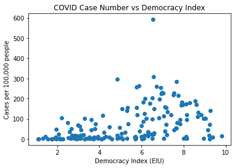

```python
plt.scatter(comb_data.eiu, comb_data.deaths)
plt.title('COVID Case Number vs Democracy Index')
plt.xlabel('Democracy Index (EIU)')
plt.ylabel('Cases per 100,000 people')
#m, b = np.polyfit(comb_data.eiu, comb_data.deaths, 1)
#plt.plot(comb_data.eiu, m*comb_data.eiu + b)

#correlation_matrix = np.corrcoef(comb_data.eiu, comb_data.deaths)
#correlation_xy = correlation_matrix[0,1]
#r_squared = correlation_xy**2
#print(correlation_xy)
#index = 0

#stat, p = pearsonr(comb_data.eiu, comb_data.deaths)

plt.show()
#print(p)
```

### Variable 2: GDP per capita

[figure not shown]

```python
plt.scatter(df.gdp, df.deaths)
plt.title('Win Percent as a function of Payroll fo')
plt.xlabel('Mean Total Payroll of Team')
plt.ylabel('Mean Win Percent of Team across bin')
#m, b = np.polyfit(df.gdp, df.deaths, 1)
#plt.plot(df.gdp, m*df.gdp + b)

#correlation_matrix = np.corrcoef(df.gdp, df.deaths)
#correlation_xy = correlation_matrix[0,1]
#r_squared = correlation_xy**2
#print(correlation_xy)
#index = 0

plt.show()
#stat, p = pearsonr(df.gdp, df.deaths)
#print(p)
```

[figure not shown]

```python
df = df.dropna()

plt.scatter(df.total_gdp, df.deaths)
plt.title('Win Percent as a function of Payroll fo')
plt.xlabel('Mean Total Payroll of Team')
plt.ylabel('Mean Win Percent of Team across bin')


plt.show()
```

[figure not shown]

```python
plt.scatter(df.press, df.deaths)
plt.title('Win Percent as a function of Payroll fo')
plt.xlabel('Mean Total Payroll of Team')
plt.ylabel('Mean Win Percent of Team across bin')

plt.show()
```

[figure not shown]

[output not shown]

[figure not shown]

```python
#pop_dens = pd.read_csv("pop_density.csv")
#pop_dens = pop_dens[['Country Code', '2018']]
#pop_dens.rename(columns = {'2018':'density'}, inplace = True)
#df = df.merge(pop_dens, left_on = 'Name', right_on = 'Country Code')
#df = df.dropna()

#plt.scatter(df.density, df.cases)
#plt.title('Win Percent as a function of Payroll fo')
#plt.xlabel('Mean Total Payroll of Team')
#plt.ylabel('Mean Win Percent of Team across bin')
#m, b = np.polyfit(df.density, df.cases, 1)
#plt.plot(df.density, m*df.density + b)

#correlation_matrix = np.corrcoef(df.density, df.cases)
#correlation_xy = correlation_matrix[0,1]
#r_squared = correlation_xy**2
#print(correlation_xy)
#index = 0


#stat, p = pearsonr(df.density, df.deaths)
#print(p)
#print(stat)
#plt.show()
```